# VaR for a Financial Portfolio

Magdalena Marecik

## Introduction

The VaR (Value at Risk) concept can be applied to analyze the risk of individual securities as well as a portfolio of such assets. It addresses the question of the potential level of loss at a given confidence level. The project aims to examine how the correlation between the return rates of securities within an investment portfolio affects the risk magnitude. The portfolio under analysis comprises three stock market indices in equal proportions:

- DAX (Deutscher Aktienindex) - the German stock market index traded on the Frankfurt Stock Exchange
- WIG - stock market index listed on the Warsaw Stock Exchange
- SMI (Swiss Market Index) - stock market index of companies listed on the Swiss Exchange

The project involves monitoring the Pearson correlation, the EWMA model, and the GARCH(1,1) model between the return rates of the above-mentioned stock market indices for the years 2006-2021. Using each model, the volatility of the investment portfolio was estimated, and then, with a time horizon T=250, the 95% VaR was determined using the variance-covariance method. In the final stage, Kupiec’s test, Christoffersen’s test, and Real Value tests were conducted to verify whether the risk level was accurately estimated.

## Exploratory data analysis

Looking at the chart below, one can presume that there is a fairly distinct relationship between the prices of the WMI, DAX, and SMI indices, which appear to exhibit a similar pattern of changes. It can be observed that both long-term and short-term price variations over time are analogous for all three indices.

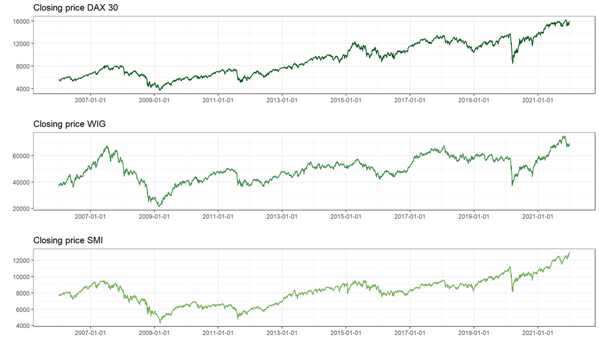

In the chart below, we can see that the closing prices of the SMI and DAX indices are similar. The closing prices of the WIG index are significantly higher than those of the other two assets because the WIG index includes a considerably larger number of companies.

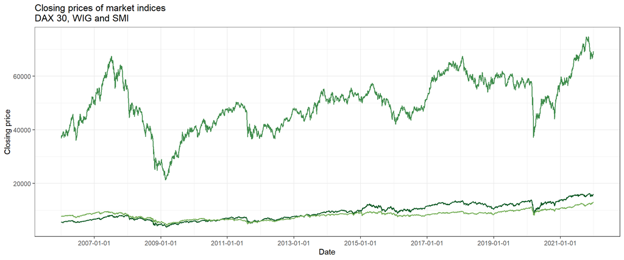

Looking at the return rate charts of individual indices, we can observe that clusters of volatility occur in similar periods. Therefore, the changes in their prices were largely shaped by the same market phenomena. The presence of larger and smaller fluctuations in the returns of all three assets at similar times allows for preliminary assumptions about the existence of relationships between the returns.

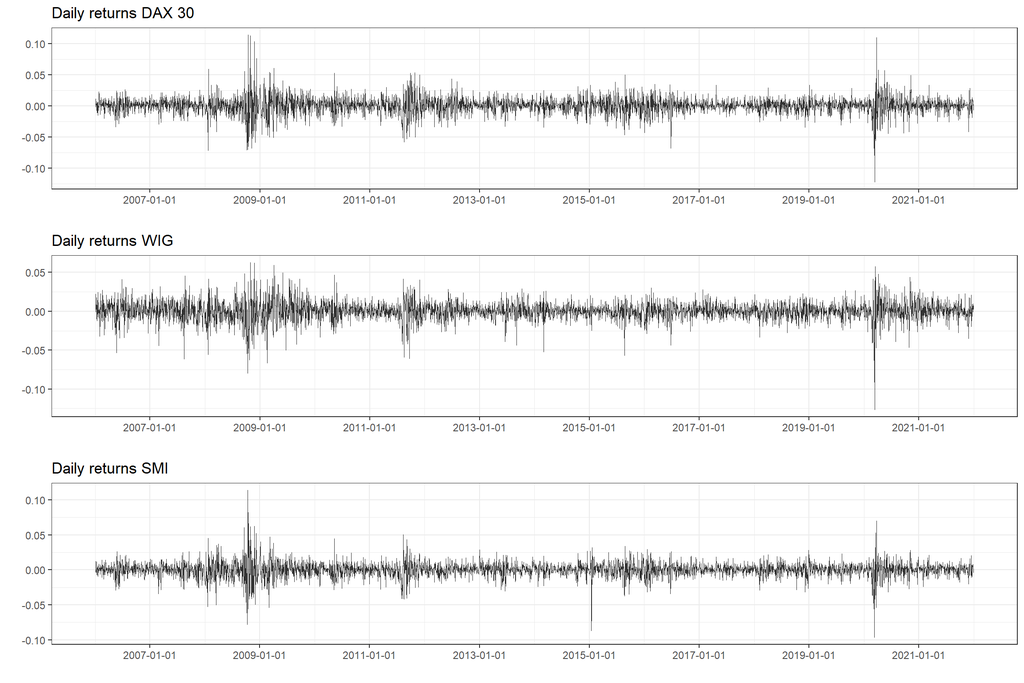

## Monitoring the coefficient of Pearson’s correlation

To understand how price changes of two assets have historically related to each other, investors construct correlation matrices. This is a tabular representation of correlation coefficients between the return rates of individual components of the portfolio.

The correlation coefficients are calculated not for the closing prices of assets but for the return rates over a selected period. This coefficient informs about the portion of price movements of two assets caused by the same market forces. Return rate correlation is not constant over time, so a method to monitor it must be found. The correlation coefficient between the returns of assets in the portfolio can be defined using Pearson’s linear correlation, considering the last T return rates:

$$\rho(V_1,V_2)=\frac{cov(V_1,V_2)}{sd(V_1)\cdot sd(V_2)}$$

$$cov(V_1,V_2) = E(V_1V_2) - E(V_1)E(V_2)$$

Pearson correlation requires the assumption of normality in return rates; otherwise, it may only serve as an approximation of the correlation of losses. Another way to monitor correlation is the EWMA (Exponentially Weighted Moving Average) model, which rightfully assigns greater weights to more recent observations. The estimated covariance of returns is calculated according to the formula:

$$cov_n = \lambda \cdot cov_{n-1} + (1-\lambda)\cdot x_{n-1}y_{n-1}$$

For updating the estimates of the covariance coefficient, the GARCH(1,1) model can also be employed:

$$cov_n = \omega + \alpha\cdot x_{n-1}y_{n-1} + \beta\cdot cov_{n-1}$$

An example correlation matrix for the discussed portfolio as of December 1, 2021, determined using the Pearson method for T=30, looks as follows:

|  | dax | smi | wig |
| --- | --- | --- | --- |
| dax | 1.0000000 | 0.8113368 | 0.5420890 |
| smi | 0.8113368 | 1.0000000 | 0.3502537 |
| wig | 0.5420890 | 0.3502537 | 1.0000000 |

The chart below illustrates the results of monitoring correlation over time, utilizing the methods and historical return rate values described earlier. All techniques yielded a similar trend in correlation, but in the charts for the EWMA method and GARCH(1,1) method, the influence of assigning weights to historical covariances is noticeable. While the Pearson correlation chart often indicates sharp declines in relationships between individual assets, the declines on the EWMA and GARCH charts are much smoother. This is because significant weights are given to high covariances occurring in the recent past. An example is the beginning of 2015 when the Pearson coefficient suggests that the correlation between WIG and DAX dropped from 0.25 to -0.2, whereas the EWMA and GARCH methods practically did not register this decline.

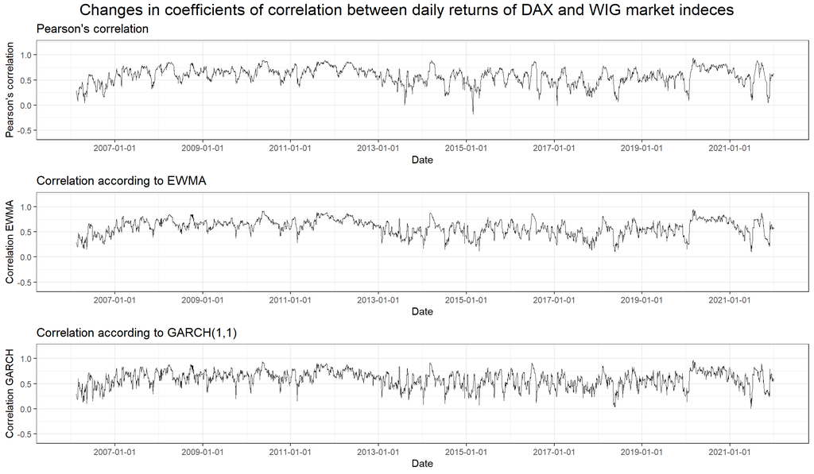

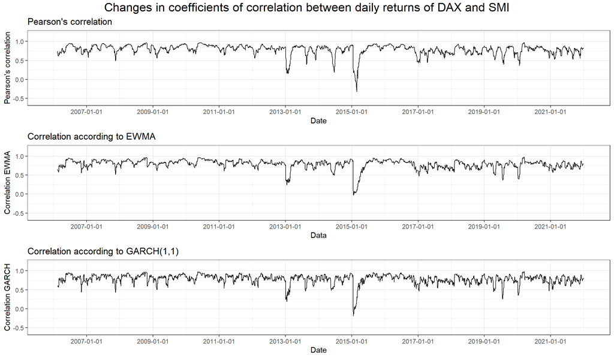

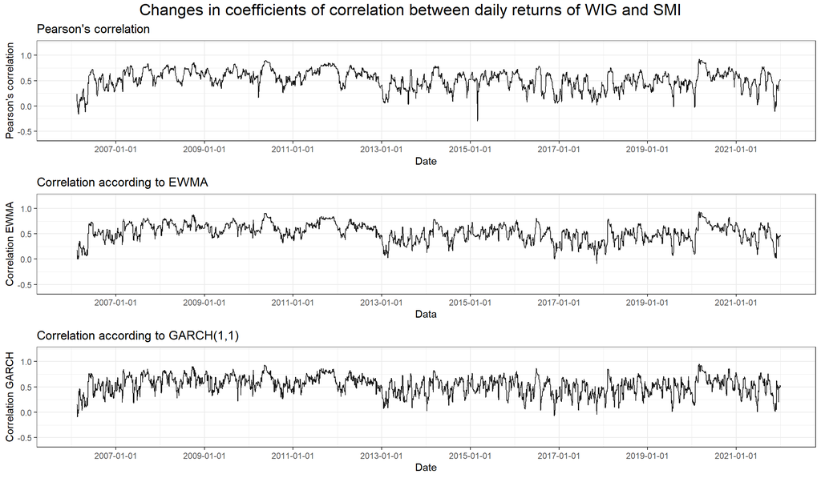

#### Why the correlation helps mitigate risk?

Understanding the correlation between changes in asset prices can help appropriately diversify a portfolio and, consequently, reduce investment risk. If a portfolio consists of a sufficient number of uncorrelated assets, the likelihood that their prices will change in the same direction at any given time becomes very low. In reality, when one component of the portfolio incurs a loss, there is a high chance that another will generate compensating profits. Therefore, a set of uncorrelated assets can be combined into a low-risk portfolio.

## Portfolio volatility

The portfolio variance is a measure of the volatility of portfolio returns. It is calculated using the standard deviation of each security within the investment portfolio, their correlations, and considering the proportion of the total portfolio represented by each asset. The formula for portfolio variance is as follows:

$$\sigma_p^2 = \sum_{i=1}^{n}\sum_{j=1}^{n}{\rho_{ij} w_i w_j \sigma_i
\sigma_j}$$

The charts below depict the volatility of an investment portfolio consisting of equal proportions of DAX, SMI, and WIG indices. To determine the return rate volatility and covariance matrix, a 250-day history was considered. The return rate volatility was estimated using the variance formula, the EWMA model, and GARCH(1,1) model, respectively, for each technique.

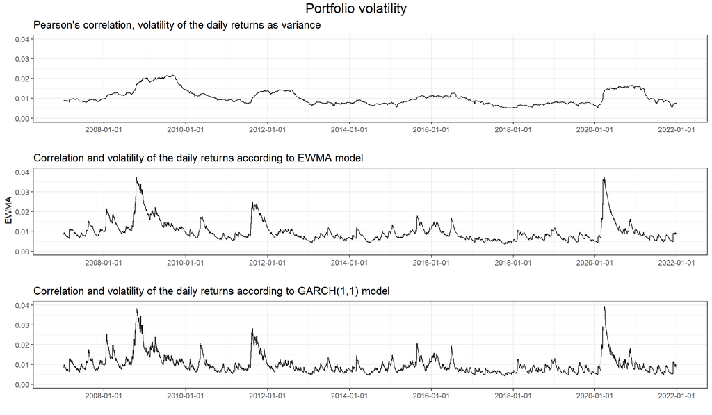

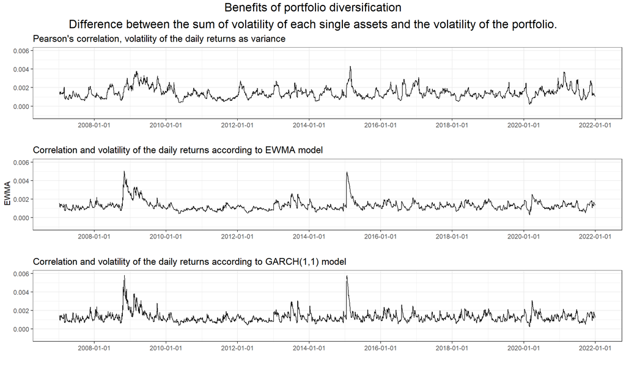

## VaR for a portfolio

The 95% Value at Risk (VaR) for the discussed investment portfolio was determined using the model-building method (the variance-covariance method). This approach requires the assumption of normality in the distribution of daily returns. The 95% VaR was calculated according to the formula below:

$$VaR_p = N^{−1}(0.95)\cdotσ_p$$

On the other hand, we approximate the return rates of the market portfolio using the weighted average of the return rates of assets comprising the portfolio, according to the formula:

$$R_p = \sum^{N}_{i=1}{w_ir_i}$$

The charts below depict how the sequence of VaR, determined by the variance-covariance method, has changed, as well as the return rates of the investment portfolio. Days where the portfolio volatility exceeded the 95% VaR are highlighted.

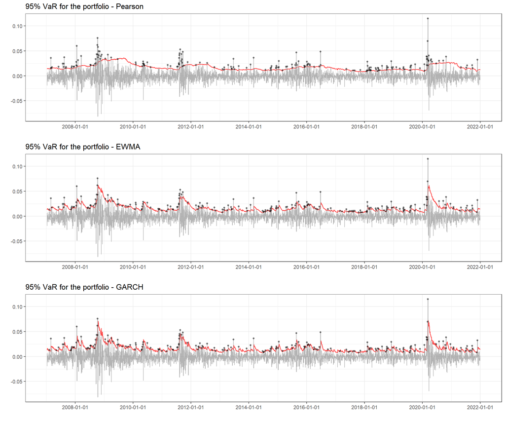

## Backward testing

To check whether the VaR determined for our market portfolio accurately assessed the risk level, a series of backtests were conducted: the Kupiec test, the Christoffersen test, and real-value tests. The table below shows, in order, the percentage of VaR exceedances for the entire period, the number of 250-day windows that passed the Kupiec test, and the p-value for the Christoffersen test for each of the VaR estimation techniques.

[output not shown]

The Christoffersen test of independence over time passed positively only for the GARCH(1,1) model. It can be considered that the GARCH(1,1) technique yielded the best results among all three risk estimation methods for the discussed portfolio.